# Untitled

B082040005 高念慈

2022-12-28

- http://uc-r.github.io/gbm_regression
- 只抓取 104-105 年，減少資料量/房價變化才不會特別劇烈

```r
KH <- filter(KH,KH$TradeYear %in% c(104,105))
```

```r
colnames(KH)[16] <- c("Type_parking_space")
colnames(KH)[18] <- c("Type_building_without_PS")
colnames(KH)[19] <- c("Type_building_with_PS")
colnames(KH)[20] <- c("Type_building_price_inclued_PS")
colnames(KH)[21] <- c("Parking_space_total_area")
colnames(KH)[22] <- c("Parking_space_price")
colnames(KH)[23] <- c("Transfer_area_land")
colnames(KH)[24] <- c("Transfer_area_building")
colnames(KH)[25] <- c("Using_type_L")
colnames(KH)[26] <- c("Using_type_B")
colnames(KH)[27] <- c("Using_type_Far")
colnames(KH)[28] <- c("Using_type_Fac")
colnames(KH)[29] <- c("Using_type_O")
colnames(KH)[30] <- c("Land_usage_city")
colnames(KH)[31] <- c("Land_usage_nonecity")
colnames(KH)[32] <- c("Land_usage_mt_preservation")
colnames(KH)[38] <- c("Building_Apt_general")
colnames(KH)[39] <- c("Building_Apt_luxury")
colnames(KH)[40] <- c("Building_Apt_WS")
```

### 處理分類變量

```r
# Dummy variable 轉成'Factor'
dat = KH %>%
  mutate(Type_parking_space = factor(Type_parking_space,levels=c(0,1),labels = c('No','Yes')),
         Type_land = factor(Type_land,levels = c(0,1),labels =c('No','Yes')),
         Type_building_without_PS = factor(Type_building_without_PS,levels = c(0,1),labels =c('No','Yes')),
         Type_building_with_PS = factor(Type_building_with_PS,levels = c(0,1),labels =c('No','Yes')),
         Type_building_price_inclued_PS = factor(Type_building_price_inclued_PS,levels = c(0,1),labels =c('No','Yes')),
         Using_type_L =  factor(Using_type_L ,levels = c(0,1),labels =c('No','Yes')),
         Using_type_B =  factor(Using_type_B ,levels = c(0,1),labels =c('No','Yes')),
         Using_type_Far = factor(Using_type_Far ,levels = c(0,1),labels =c('No','Yes')),
         Using_type_Fac = factor(Using_type_Fac ,levels = c(0,1),labels =c('No','Yes')),
         Using_type_O = factor(Using_type_O ,levels = c(0,1),labels =c('No','Yes')),
         Land_usage_city = factor(Land_usage_city ,levels = c(0,1),labels =c('No','Yes')),
         Land_usage_nonecity = factor(Land_usage_nonecity ,levels = c(0,1),labels =c('No','Yes')),
         Land_usage_mt_preservation = factor(Land_usage_mt_preservation ,levels = c(0,1),labels =c('No','Yes')),

         Building_age_nodata = factor( Building_age_nodata ,levels = c(0,1),labels =c('No','Yes')),
         Building_Apt_general = factor(Building_Apt_general,levels = c(0,1),labels =c('No','Yes')),
         Building_Apt_luxury = factor(Building_Apt_luxury,levels = c(0,1),labels =c('No','Yes')),
         Building_Apt_WS =  factor(Building_Apt_WS,levels = c(0,1),labels =c('No','Yes')),
         Building_House  =  factor( Building_House,levels = c(0,1),labels =c('No','Yes')),
         Building_Suit  =  factor( Building_Suit,levels = c(0,1),labels =c('No','Yes')),
         Building_Others = factor( Building_Others,levels = c(0,1),labels =c('No','Yes'))
         )
```

```r
# str(df)
colnames(dat)
```

```
##  [1] "Seq_no-old"                     "X"
##  [3] "Y"                              "Location_Town"
##  [5] "Location_TownIDOld"             "Location_TownID"
##  [7] "Location_Li"                    "TradeYear"
##  [9] "TradeYQ"                        "TdSeason"
## [11] "TradeYM"                        "TradeYMD"
## [13] "Price_total"                    "Price_unit"
## [15] "Priceunit_nodata"               "Type_parking_space"
## [17] "Type_land"                      "Type_building_without_PS"
## [19] "Type_building_with_PS"          "Type_building_price_inclued_PS"
## [21] "Parking_space_total_area"       "Parking_space_price"
## [23] "Transfer_area_land"             "Transfer_area_building"
## [25] "Using_type_L"                   "Using_type_B"
## [27] "Using_type_Far"                 "Using_type_Fac"
## [29] "Using_type_O"                   "Land_usage_city"
```

[output cut: 26 more lines]

### 資料

- 目標變數 : “Price_total”，交易總價(萬)

### 主要關心變數

- “temple_distant”

#### 刪，避免資訊洩漏

- “Price_unit”，每平方公尺交易價格(萬) ???
- “Priceunit_nodata”，無每平方公尺交易價格資料 ???

#### 刪，不重要/重複資訊/模型不能直接跑的變數(chr.)

- “Seq_no-old”
- “Location_Town”
- “Location_Li”
- “geometry”

#### 剩下資料讓模型自行篩選

```r
#dat = dat[,-c("Location_TownIDOld","Price_unit","Priceunit_nodata")]

dat = dat[,-c("Seq_no-old","Location_TownIDOld","Price_unit","Priceunit_nodata","Location_Town","Location_Li","geometry")]

#dat = dat[,-c("房屋類別")]
```

### 切資料/rescale(提高變數解釋性/收斂速度)

最後把目標變數取 log (預設底數 exp ，期中的圖應該也是底數為 exp 的)  
以防模型訓練不出明顯差距

```r
# Split dataset training (70%) and testing (30%)

set.seed(1)
train_idx <- sample(1:nrow(dat), nrow(dat) * 0.3)
# test_idx <- sample(1:nrow(dat), nrow(dat) * 0.5)
train <- dat[train_idx, ]
test <-  dat[setdiff(1:nrow(dat), train_idx),]
test = test[1:9000,]

#train_idx <- sample(1:nrow(dat), nrow(dat) * 0.7)
#train <- dat[train_idx, ]
#test <- dat[setdiff(1:nrow(dat), train_idx),]

# rescale

train_y = train[, c("Price_total")]
test_y = test[ , c("Price_total")]

rescale <- preProcess(train[, -c("Price_total")], method = c("center", "scale"))
# double check with method
# rescale$method
scaled_train <- predict(rescale, train[, -c("Price_total")])
scaled_test <- predict(rescale, test[, -c("Price_total")])

scaled_train[, c("Price_total")] = log(train[, c("Price_total")])
scaled_test[, c("Price_total")] = log(test[ , c("Price_total")])

#scaled_train = scaled_train[,-c("Type_parking_space")]
#scaled_test = scaled_test[,-c("Type_parking_space")]
```

```r
# write.csv(dat,file = "C:/Users/user/Desktop/bigdata_HW/期中期末/Group12/Dataset/KH(5).csv")

# write.csv(scaled_test,file = "C:/Users/user/Desktop/bigdata_HW/期中期末/Group12/Dataset/scaled_test1.csv")
```

### model

```r
# install.packages('gbm')
library(gbm)
```

gbm( + formula = formula(data),模型公式(可加offset) + distribution = “bernoulli”,各種分佈函數都可

“gaussian”（平方誤差）、“laplace”（絕對損失）、“tdist”（t 分佈損失） “adaboost”（0-1 結果的 AdaBoost 指數損失）、“bernoulli”（0-1 結果的邏輯回歸）…

- data = list(),不能 NA，dataframe
- weights,權重
- var.monotone = NULL,假設預測變量和標籤的關係，（大概是可以減少運算速度吧）
- n.trees = 100,迭代回歸樹的數量，一般來說先越大越好，然後選擇合適的數目。
- n.minobsinnode = 10,樹終節點的最小個數
- shrinkage = 0.001,收縮率，也叫學習速率，一般先設置0.1左右
- interaction.depth = 1,樹的深度
- train.fraction = 1.0,train.fraction * nrows(data) 觀察值用於擬合 gbm，其餘部分用於計算損失函數的樣本外估計
- bag.fraction = 0.5,隨機選擇的訓練集觀察的分數，以提出擴展中的下一棵樹
- cv.folds=0,交叉驗證的則數，可以用來提取最適的回歸樹數目
- keep.data = TRUE,一般為TRUE，可以加快速度
- verbose = “CV”,TRUE的話可以反饋結果。
- class.stratify.cv = NULL,
- n.cores = NULL)，使用CPU核心的數量

為了減少變數選取我在此先訓練一個大的model  
抓出模型中變數重要性不為 0 的變數或前 30 個變數  
使用 5-fold ，學習率 0.1 ，訓練 200 顆數，找出最適驗證集或測試集顆數

```r
starttime =  now()

model_gbm = gbm(scaled_train$Price_total ~.,
                data = scaled_train,
                distribution = "gaussian",
                cv.folds = 5,
                shrinkage = 0.1,
                n.minobsinnode = 10,
                n.trees = 200,
                interaction.depth = 6,
                bag.fraction = 0.5,
                train.fraction = 0.6,
                keep.data = TRUE,
                verbose = TRUE)
```

```
##      1        1.4072          1.2981     0.1000    0.1527
##      2        1.2817          1.1785     0.1000    0.1239
##      3        1.1775          1.0801     0.1000    0.1061
##      4        1.0731          0.9795     0.1000    0.1068
##      5        0.9798          0.8896     0.1000    0.0867
##      6        0.9038          0.8169     0.1000    0.0752
##      7        0.8449          0.7620     0.1000    0.0575
##      8        0.7884          0.7110     0.1000    0.0534
##      9        0.7315          0.6592     0.1000    0.0538
##     10        0.6885          0.6197     0.1000    0.0426
##     20        0.4356          0.3969     0.1000    0.0121
##     40        0.2883          0.2722     0.1000    0.0029
##     60        0.2435          0.2382     0.1000    0.0007
##     80        0.2214          0.2234     0.1000    0.0004
##    100        0.2067          0.2125     0.1000    0.0003
##    120        0.1968          0.2065     0.1000   -0.0004
##    140        0.1889          0.2006     0.1000    0.0000
##    160        0.1827          0.1982     0.1000   -0.0002
##    180        0.1771          0.1952     0.1000   -0.0001
##    200        0.1723          0.1928     0.1000   -0.0003
```

```r
endtime = now()

print(endtime - starttime)
```

```
## Time difference of 36.46552 secs
```

```r
difftime(endtime,starttime, units = 'mins')
```

```
## Time difference of 0.6077587 mins
```

- The best cross-validation iteration was 200.
- The best test-set iteration was 198.
- There were 73 predictors of which 51 had non-zero influence.

在這裡有 51 個變數都有非 0 的影響，但資料太大，不同 model 給出的數量不同  
決定超過 30 就用 30 上下做/看重要性結果決定變數做最後的 model

```r
print(model_gbm)
```

```
## gbm(formula = scaled_train$Price_total ~ ., distribution = "gaussian",
##     data = scaled_train, n.trees = 200, interaction.depth = 6,
##     n.minobsinnode = 10, shrinkage = 0.1, bag.fraction = 0.5,
##     train.fraction = 0.6, cv.folds = 5, keep.data = TRUE, verbose = TRUE)
## A gradient boosted model with gaussian loss function.
## 200 iterations were performed.
## The best cross-validation iteration was 200.
## The best test-set iteration was 198.
## There were 73 predictors of which 51 had non-zero influence.
```

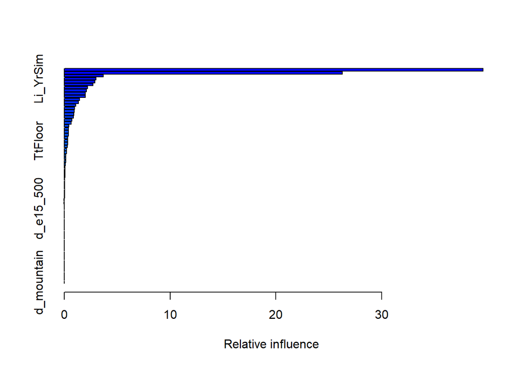

```
##                                                           var      rel.inf
## Transfer_area_building                 Transfer_area_building 39.584965536
## Transfer_area_land                         Transfer_area_land 26.271679512
## distance_LRT                                     distance_LRT  3.705999924
## Li_YrSim                                             Li_YrSim  3.009570351
## Build_YMD                                           Build_YMD  2.891706479
## Land_usage_city                               Land_usage_city  2.702591799
## Location_Income                               Location_Income  2.204078548
## Li_SSSim                                             Li_SSSim  2.098003879
## distance_train                                 distance_train  2.006204831
## Type_land                                           Type_land  1.989252937
## Build_YM                                             Build_YM  1.445214733
## distance_interchange                     distance_interchange  1.340760210
## Build_Y                                               Build_Y  1.074437577
## X                                                           X  0.983170113
## temple_distant                                 temple_distant  0.952324135
## Town_Season                                       Town_Season  0.919452874
## Land_usage_mt_preservation         Land_usage_mt_preservation  0.874548212
## distance_factory                             distance_factory  0.711504878
## Using_type_L                                     Using_type_L  0.638715078
## Using_type_Far                                 Using_type_Far  0.440285838
## TradeYMD                                             TradeYMD  0.413573726
## Y                                                           Y  0.402719498
## Building_age                                     Building_age  0.388970124
## distance_airport                             distance_airport  0.342721600
## TtFloor                                               TtFloor  0.329911860
## Using_type_O                                     Using_type_O  0.327686101
## Using_type_B                                     Using_type_B  0.309253290
## Floor_transfer                                 Floor_transfer  0.236487996
## NoManageOrg                                       NoManageOrg  0.220610449
## Type_building_with_PS                   Type_building_with_PS  0.159363540
## Li_Year                                               Li_Year  0.153852795
## Floor_complex                                   Floor_complex  0.135749961
## Building_Apt_general                     Building_Apt_general  0.117580846
## Building_Others                               Building_Others  0.080349197
## Type_building_without_PS             Type_building_without_PS  0.070402680
## Pattern_room                                     Pattern_room  0.065325643
## Town_Year                                           Town_Year  0.061283852
## Pattern_hall                                     Pattern_hall  0.048799224
## Floor_nodata                                     Floor_nodata  0.046003864
```

[output cut: 19 more lines]

```
## Building_Apt_WS                               Building_Apt_WS  0.000000000
## Building_House                                 Building_House  0.000000000
## Building_Suit                                   Building_Suit  0.000000000
## Pattern_room_nodata                       Pattern_room_nodata  0.000000000
## Pattern_hall_nodata                       Pattern_hall_nodata  0.000000000
## Pattern_bath_nodata                       Pattern_bath_nodata  0.000000000
## Pattern_non                                       Pattern_non  0.000000000
## d_e46_500                                           d_e46_500  0.000000000
## d_e46_1000                                         d_e46_1000  0.000000000
## d_e11_500                                           d_e11_500  0.000000000
## d_e11_1000                                         d_e11_1000  0.000000000
## d_e11_2000                                         d_e11_2000  0.000000000
## d_e15_1000                                         d_e15_1000  0.000000000
## d_e15_2000                                         d_e15_2000  0.000000000
## d_mountain                                         d_mountain  0.000000000
```

```r
# install.packages("png")
# library(png)
# filename="C:/Users/user/Desktop/bigdata_HW/期中期末/Group12/Dataset/Rplot%03d.png"
summary(model_gbm)
```

```r
sqrt(min(model_gbm$cv.error))
```

```
## [1] 0.4747995
```

```r
min(model_gbm$cv.error)
```

```
## [1] 0.2254346
```

### 最適回歸樹顆數

- 紅 TEST
- 綠 VAL
- 黑 TRAIN

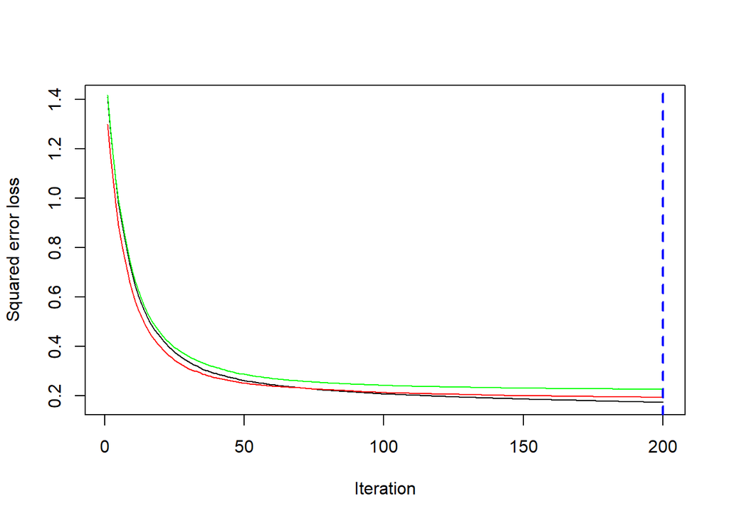

```r
besttree = gbm.perf(model_gbm,
                    plot.it = TRUE,
                    oobag.curve = F,
                    overlay = TRUE,
                    method="cv")
```

```r
besttree # 200
```

```
## [1] 200
```

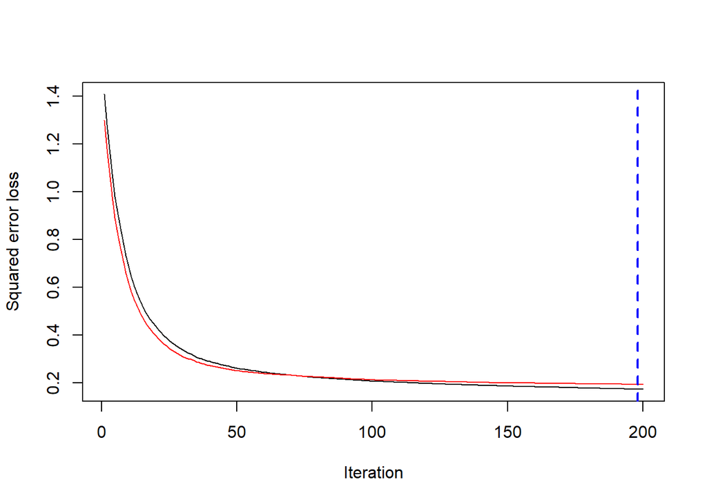

```r
besttree = gbm.perf(model_gbm,
                    plot.it = TRUE,
                    oobag.curve = F,
                    overlay = TRUE,
                    method="test")
```

```r
besttree # 198
```

```
## [1] 198
```

### 預測

```r
pred_y = predict(model_gbm, scaled_test)
```

```
## Using 198 trees...
```

```r
#########################

train_pred_y = predict(model_gbm, scaled_train)
```

```
## Using 198 trees...
```

以下皆是取完對數後的結果 :

```r
residuals = log(test_y) - pred_y
RMSE = sqrt(mean(unlist(residuals^2)))
cat('The root mean square error of the test data is ', round(RMSE,3),'\n')
```

```
## The root mean square error of the test data is  0.46
```

```r
y_test_mean = mean(unlist(log(test_y)))
# Calculate total sum of squares
tss =  sum((unlist(log(test_y)) - y_test_mean)^2 )
# Calculate residual sum of squares
rss =  sum(residuals^2)
# Calculate R-squared
rsq  =  1 - (rss/tss)
cat('The R-square of the test data is ', round(rsq,3), '\n')
```

```
## The R-square of the test data is  0.853
```

```r
##############################################

train_residuals = log(train_y) - train_pred_y
train_RMSE = sqrt(mean(unlist(train_residuals^2)))
cat('The root mean square error of the train data is ', round(RMSE,3),'\n')
```

```
## The root mean square error of the train data is  0.46
```

```r
y_train_mean = mean(unlist(log(train_y)))
# Calculate total sum of squares
tss =  sum((unlist(log(train_y)) - y_train_mean)^2 )
# Calculate residual sum of squares
rss =  sum(train_residuals^2)
# Calculate R-squared
rsq  =  1 - (rss/tss)
cat('The R-square of the train data is ', round(rsq,3), '\n')
```

```
## The R-square of the train data is  0.881
```

- 從圖中(測試集結果)可看到模型訓練的不差，紅色為預測，藍色為實際值

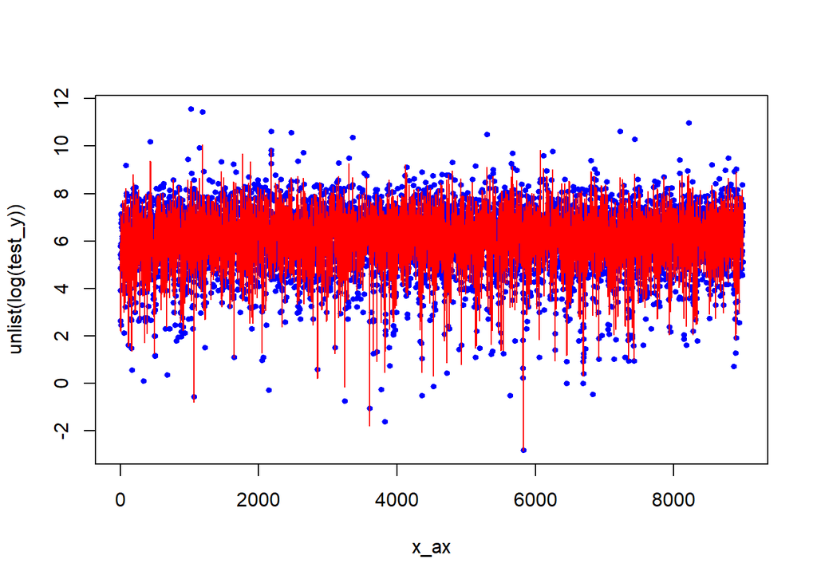

```r
# visualize the model, actual and predicted data
x_ax = 1:length(pred_y)
plot(x_ax, unlist(log(test_y)), col="blue", pch=20, cex=.9)
lines(x_ax, pred_y, col="red", pch=20, cex=.9)
```

- https://blog.csdn.net/langyichao1/article/details/70175715
- 變數重要性圖

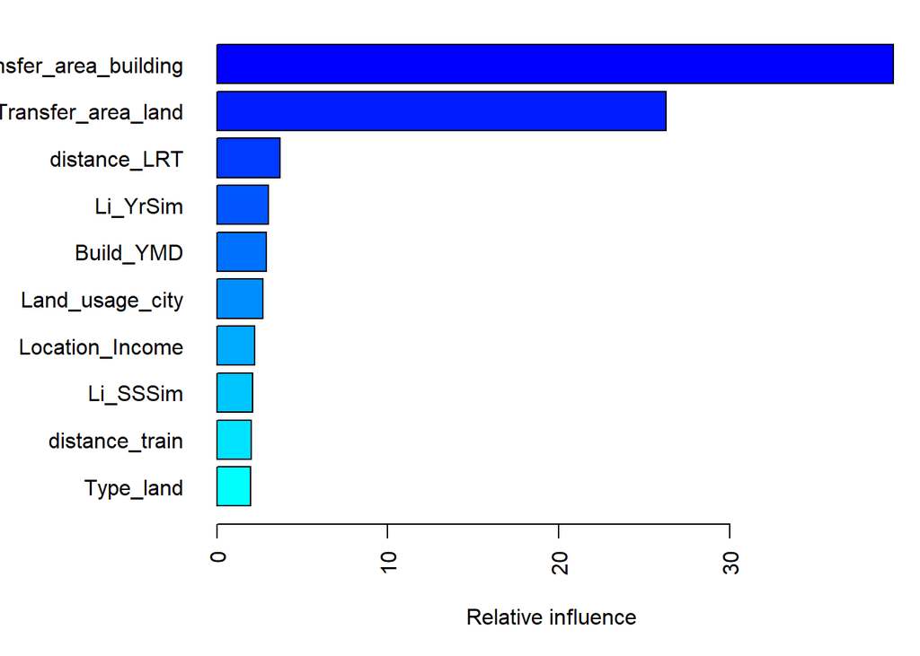

```
##                                                           var      rel.inf
## Transfer_area_building                 Transfer_area_building 39.584965536
## Transfer_area_land                         Transfer_area_land 26.271679512
## distance_LRT                                     distance_LRT  3.705999924
## Li_YrSim                                             Li_YrSim  3.009570351
## Build_YMD                                           Build_YMD  2.891706479
## Land_usage_city                               Land_usage_city  2.702591799
## Location_Income                               Location_Income  2.204078548
## Li_SSSim                                             Li_SSSim  2.098003879
## distance_train                                 distance_train  2.006204831
## Type_land                                           Type_land  1.989252937
## Build_YM                                             Build_YM  1.445214733
## distance_interchange                     distance_interchange  1.340760210
## Build_Y                                               Build_Y  1.074437577
## X                                                           X  0.983170113
## temple_distant                                 temple_distant  0.952324135
## Town_Season                                       Town_Season  0.919452874
## Land_usage_mt_preservation         Land_usage_mt_preservation  0.874548212
## distance_factory                             distance_factory  0.711504878
## Using_type_L                                     Using_type_L  0.638715078
## Using_type_Far                                 Using_type_Far  0.440285838
## TradeYMD                                             TradeYMD  0.413573726
## Y                                                           Y  0.402719498
## Building_age                                     Building_age  0.388970124
## distance_airport                             distance_airport  0.342721600
## TtFloor                                               TtFloor  0.329911860
## Using_type_O                                     Using_type_O  0.327686101
## Using_type_B                                     Using_type_B  0.309253290
## Floor_transfer                                 Floor_transfer  0.236487996
## NoManageOrg                                       NoManageOrg  0.220610449
## Type_building_with_PS                   Type_building_with_PS  0.159363540
## Li_Year                                               Li_Year  0.153852795
## Floor_complex                                   Floor_complex  0.135749961
## Building_Apt_general                     Building_Apt_general  0.117580846
## Building_Others                               Building_Others  0.080349197
## Type_building_without_PS             Type_building_without_PS  0.070402680
## Pattern_room                                     Pattern_room  0.065325643
## Town_Year                                           Town_Year  0.061283852
## Pattern_hall                                     Pattern_hall  0.048799224
## Floor_nodata                                     Floor_nodata  0.046003864
```

[output cut: 19 more lines]

```
## Building_Apt_WS                               Building_Apt_WS  0.000000000
## Building_House                                 Building_House  0.000000000
## Building_Suit                                   Building_Suit  0.000000000
## Pattern_room_nodata                       Pattern_room_nodata  0.000000000
## Pattern_hall_nodata                       Pattern_hall_nodata  0.000000000
## Pattern_bath_nodata                       Pattern_bath_nodata  0.000000000
## Pattern_non                                       Pattern_non  0.000000000
## d_e46_500                                           d_e46_500  0.000000000
## d_e46_1000                                         d_e46_1000  0.000000000
## d_e11_500                                           d_e11_500  0.000000000
## d_e11_1000                                         d_e11_1000  0.000000000
## d_e11_2000                                         d_e11_2000  0.000000000
## d_e15_1000                                         d_e15_1000  0.000000000
## d_e15_2000                                         d_e15_2000  0.000000000
## d_mountain                                         d_mountain  0.000000000
```

```r
par(mar = c(5, 8, 1, 1))
# S3 method for class 'gbm'
summary(
  model_gbm, # gbm object
  cBars = 10, # the number of bars to draw. length(object$var.names)
  plotit = TRUE, # an indicator as to whether the plot is generated.defult TRUE.
  method = relative.influence, # The function used to compute the relative influence. 亦可使用permutation.test.gbm
  las = 2
  )
```

- 變數重要性圖

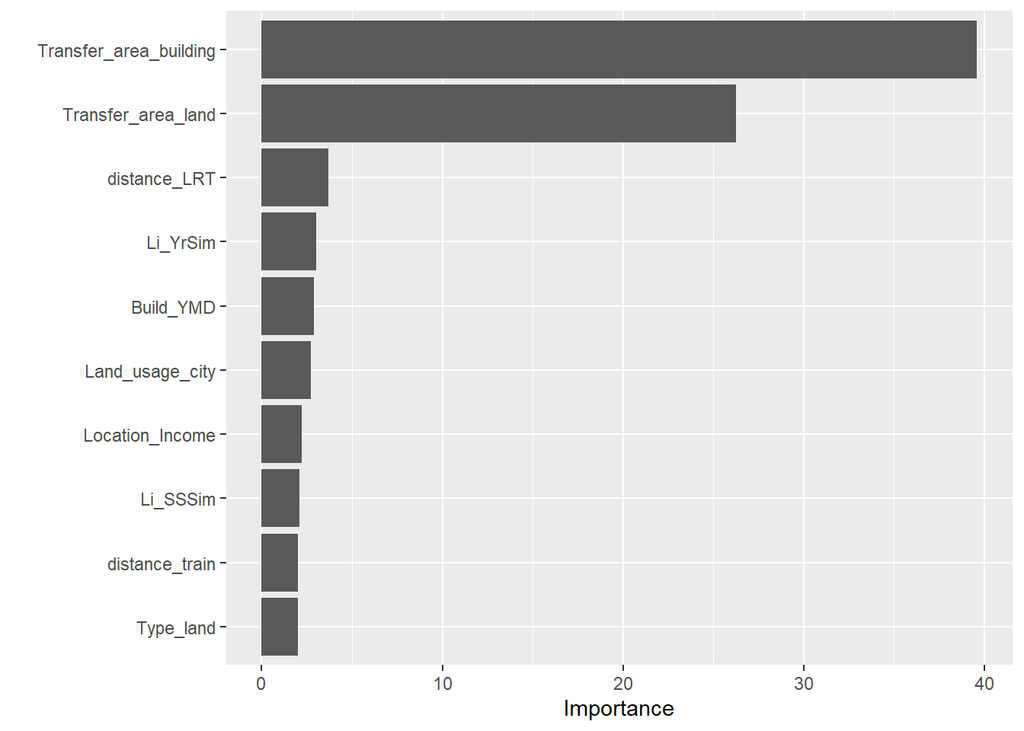

```r
# install.packages('vip')
vip::vip(model_gbm)
```

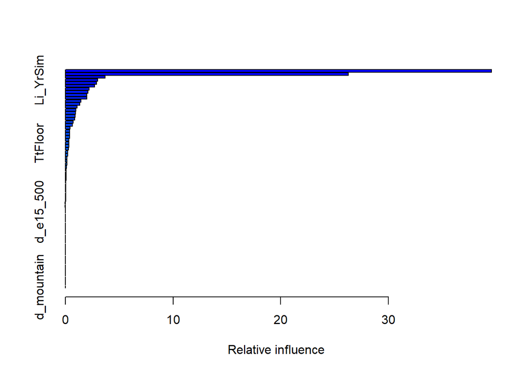

```r
importance = summary.gbm(model_gbm, plotit=TRUE)
```

```r
head(importance,35)
```

```
##                                                   var     rel.inf
## Transfer_area_building         Transfer_area_building 39.58496554
## Transfer_area_land                 Transfer_area_land 26.27167951
## distance_LRT                             distance_LRT  3.70599992
## Li_YrSim                                     Li_YrSim  3.00957035
## Build_YMD                                   Build_YMD  2.89170648
## Land_usage_city                       Land_usage_city  2.70259180
## Location_Income                       Location_Income  2.20407855
## Li_SSSim                                     Li_SSSim  2.09800388
## distance_train                         distance_train  2.00620483
## Type_land                                   Type_land  1.98925294
## Build_YM                                     Build_YM  1.44521473
## distance_interchange             distance_interchange  1.34076021
## Build_Y                                       Build_Y  1.07443758
## X                                                   X  0.98317011
## temple_distant                         temple_distant  0.95232413
## Town_Season                               Town_Season  0.91945287
## Land_usage_mt_preservation Land_usage_mt_preservation  0.87454821
## distance_factory                     distance_factory  0.71150488
## Using_type_L                             Using_type_L  0.63871508
## Using_type_Far                         Using_type_Far  0.44028584
## TradeYMD                                     TradeYMD  0.41357373
## Y                                                   Y  0.40271950
## Building_age                             Building_age  0.38897012
## distance_airport                     distance_airport  0.34272160
## TtFloor                                       TtFloor  0.32991186
## Using_type_O                             Using_type_O  0.32768610
## Using_type_B                             Using_type_B  0.30925329
## Floor_transfer                         Floor_transfer  0.23648800
## NoManageOrg                               NoManageOrg  0.22061045
## Type_building_with_PS           Type_building_with_PS  0.15936354
## Li_Year                                       Li_Year  0.15385279
## Floor_complex                           Floor_complex  0.13574996
## Building_Apt_general             Building_Apt_general  0.11758085
## Building_Others                       Building_Others  0.08034920
## Type_building_without_PS     Type_building_without_PS  0.07040268
```

- 開始創造挑選完變數後真的的模型

Transfer_area_building Transfer_area_building 39.58496554  
Transfer_area_land Transfer_area_land 26.27167951  
distance_LRT distance_LRT 3.70599992  
Li_YrSim Li_YrSim 3.00957035  
Build_YMD Build_YMD 2.89170648  
Land_usage_city Land_usage_city 2.70259180  
Location_Income Location_Income 2.20407855  
Li_SSSim Li_SSSim 2.09800388  
distance_train distance_train 2.00620483  
Type_land Type_land 1.98925294

Build_YM Build_YM 1.44521473  
distance_interchange distance_interchange 1.34076021  
Build_Y Build_Y 1.07443758  
X X 0.98317011  
temple_distant temple_distant 0.95232413  
Town_Season Town_Season 0.91945287  
Land_usage_mt_preservation Land_usage_mt_preservation 0.87454821  
distance_factory distance_factory 0.71150488  
Using_type_L Using_type_L 0.63871508  
Using_type_Far Using_type_Far 0.44028584

TradeYMD TradeYMD 0.41357373  
Y Y 0.40271950  
Building_age Building_age 0.38897012  
distance_airport distance_airport 0.34272160  
TtFloor TtFloor 0.32991186  
Using_type_O Using_type_O 0.32768610  
Using_type_B Using_type_B 0.30925329  
Floor_transfer Floor_transfer 0.23648800  
NoManageOrg NoManageOrg 0.22061045  
Type_building_with_PS Type_building_with_PS 0.15936354

Li_Year Li_Year 0.15385279  
Floor_complex Floor_complex 0.13574996  
Building_Apt_general Building_Apt_general 0.11758085  
Building_Others Building_Others 0.08034920

```r
# head(importance,33)["var"]


new_scaled_test = scaled_test[,c("X","Y","Transfer_area_building","Transfer_area_land","Build_YMD",
                                 "Land_usage_city","temple_distant","TradeYMD","Type_land","Build_YM","Land_usage_mt_preservation",
                                 "TtFloor","Using_type_L","Building_age","Floor_transfer","Using_type_B","Using_type_O",
                                 "Building_Apt_general","Using_type_Far","Building_Others","Build_Y","Type_building_with_PS",
                                 'distance_LRT','distance_train','Li_YrSim','Location_Income','Li_SSSim','distance_interchange',
                                 'distance_factory','Town_Season', 'distance_airport',"NoManageOrg","Li_Year","Floor_complex","Price_total")]

new_scaled_train = scaled_train[,c("X","Y","Transfer_area_building","Transfer_area_land","Build_YMD",
                                 "Land_usage_city","temple_distant","TradeYMD","Type_land","Build_YM","Land_usage_mt_preservation",
                                 "TtFloor","Using_type_L","Building_age","Floor_transfer","Using_type_B","Using_type_O",
                                 "Building_Apt_general","Using_type_Far","Building_Others","Build_Y","Type_building_with_PS",
                                 'distance_LRT','distance_train','Li_YrSim','Location_Income','Li_SSSim','distance_interchange',
                                 'distance_factory','Town_Season', 'distance_airport',"NoManageOrg","Li_Year","Floor_complex","Price_total")]



# test_y
# train_y
```

```r
# write.csv(new_scaled_test,file = "C:/Users/user/Desktop/bigdata_HW/期中期末/Group12/Dataset/new_scaled_test.csv")

# write.csv(new_scaled_train,file = "C:/Users/user/Desktop/bigdata_HW/期中期末/Group12/Dataset/new_scaled_train.csv")
```

- shrinkage = 0.05
- n.trees = 1000
- cv.folds = 5

```r
starttime =  now()

model_gbm = gbm(new_scaled_train$Price_total ~.,
                data = new_scaled_train,
                distribution = "gaussian",
                cv.folds = 5,
                shrinkage = 0.05,
                n.minobsinnode = 10,
                n.trees = 1000,
                interaction.depth = 6,
                bag.fraction = 0.7,
                train.fraction = 0.7,
                keep.data = TRUE,
                verbose = TRUE)
```

```
##      1        1.4574          1.3989     0.0500    0.0805
##      2        1.3865          1.3305     0.0500    0.0703
##      3        1.3210          1.2675     0.0500    0.0645
##      4        1.2630          1.2103     0.0500    0.0597
##      5        1.2071          1.1556     0.0500    0.0529
##      6        1.1560          1.1047     0.0500    0.0510
##      7        1.1020          1.0509     0.0500    0.0522
##      8        1.0523          1.0019     0.0500    0.0504
##      9        1.0116          0.9621     0.0500    0.0408
##     10        0.9719          0.9236     0.0500    0.0413
##     20        0.6787          0.6417     0.0500    0.0228
##     40        0.4357          0.4133     0.0500    0.0068
##     60        0.3377          0.3228     0.0500    0.0023
##     80        0.2885          0.2764     0.0500    0.0014
##    100        0.2603          0.2526     0.0500    0.0004
```

[output cut: 45 more lines]

```r
endtime = now()

print(endtime - starttime)
```

```
## Time difference of 1.479171 mins
```

```r
difftime(endtime,starttime, units = 'mins')
```

```
## Time difference of 1.479171 mins
```

```r
print(model_gbm)
```

```
## gbm(formula = new_scaled_train$Price_total ~ ., distribution = "gaussian",
##     data = new_scaled_train, n.trees = 1000, interaction.depth = 6,
##     n.minobsinnode = 10, shrinkage = 0.05, bag.fraction = 0.7,
##     train.fraction = 0.7, cv.folds = 5, keep.data = TRUE, verbose = TRUE)
## A gradient boosted model with gaussian loss function.
## 1000 iterations were performed.
## The best cross-validation iteration was 990.
## The best test-set iteration was 999.
## There were 34 predictors of which 34 had non-zero influence.
```

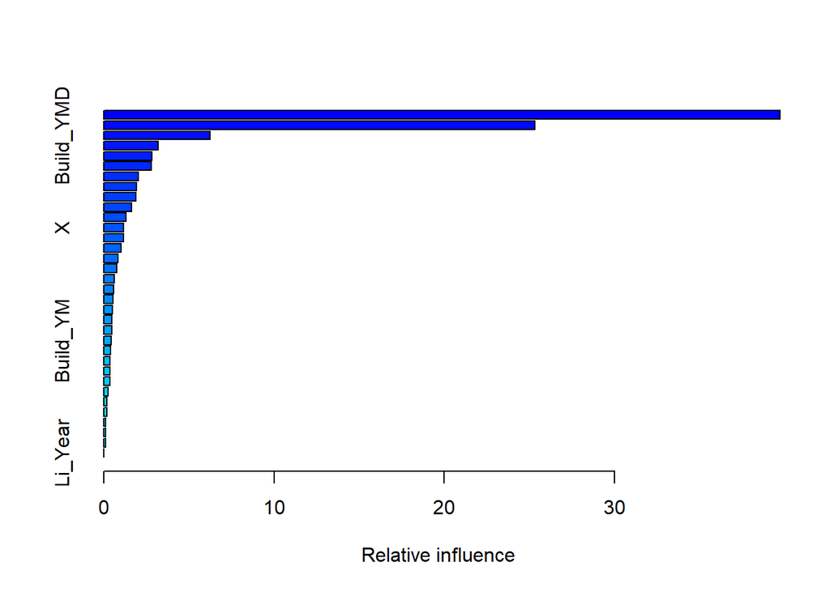

```
##                                                   var     rel.inf
## Transfer_area_building         Transfer_area_building 39.71717398
## Transfer_area_land                 Transfer_area_land 25.33318231
## Build_YMD                                   Build_YMD  6.22969193
## distance_LRT                             distance_LRT  3.19345561
## Land_usage_city                       Land_usage_city  2.83438256
## Li_SSSim                                     Li_SSSim  2.80870248
## distance_train                         distance_train  2.03783835
## Location_Income                       Location_Income  1.91463404
## Li_YrSim                                     Li_YrSim  1.88187023
## Town_Season                               Town_Season  1.64273982
## distance_interchange             distance_interchange  1.32527718
## X                                                   X  1.16281229
## Type_land                                   Type_land  1.15146968
## temple_distant                         temple_distant  1.03154751
## distance_factory                     distance_factory  0.85134846
## Land_usage_mt_preservation Land_usage_mt_preservation  0.75210998
## Y                                                   Y  0.63070695
## Using_type_L                             Using_type_L  0.56934456
## distance_airport                     distance_airport  0.53543687
## Building_age                             Building_age  0.50052594
## TradeYMD                                     TradeYMD  0.47397602
## TtFloor                                       TtFloor  0.46029444
## Build_YM                                     Build_YM  0.44202317
## Using_type_O                             Using_type_O  0.38511694
## Floor_transfer                         Floor_transfer  0.37816967
## Using_type_Far                         Using_type_Far  0.37068026
## Using_type_B                             Using_type_B  0.36911719
## NoManageOrg                               NoManageOrg  0.27478024
## Building_Others                       Building_Others  0.19863610
## Build_Y                                       Build_Y  0.19807706
## Building_Apt_general             Building_Apt_general  0.12791724
## Floor_complex                           Floor_complex  0.10165055
## Type_building_with_PS           Type_building_with_PS  0.09964161
## Li_Year                                       Li_Year  0.01566876
```

```r
summary(model_gbm)
```

```r
sqrt(min(model_gbm$cv.error))
```

```
## [1] 0.4563875
```

```r
min(model_gbm$cv.error)
```

```
## [1] 0.2082896
```

### 最適回歸樹顆數

- 紅 TEST
- 綠 VAL
- 黑 TRAIN

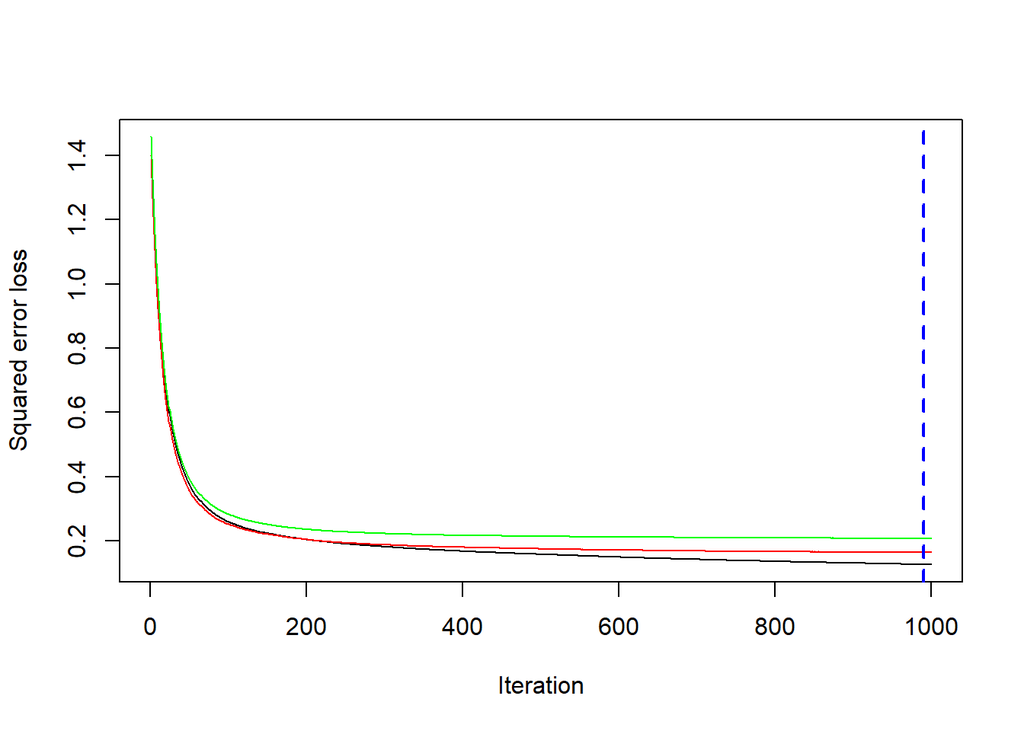

```r
besttree = gbm.perf(model_gbm,
                    plot.it = TRUE,
                    oobag.curve = F,
                    overlay = TRUE,
                    method="cv")
```

```r
besttree # 990
```

```
## [1] 990
```

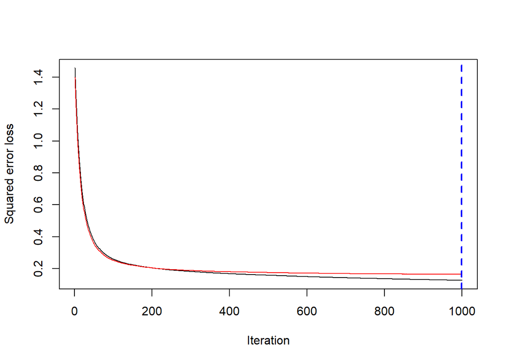

```r
besttree = gbm.perf(model_gbm,
                    plot.it = TRUE,
                    oobag.curve = F,
                    overlay = TRUE,
                    method="test")
```

```r
besttree # 999
```

```
## [1] 999
```

### 預測

```r
pred_y = predict(model_gbm, new_scaled_test)
```

```
## Using 999 trees...
```

```r
#########################

train_pred_y = predict(model_gbm, new_scaled_train)
```

```
## Using 999 trees...
```

以下皆是取完對數後的結果 :

**Using 999 trees…(樹的最適棵樹)**

```r
residuals = log(test_y) - pred_y
RMSE = sqrt(mean(unlist(residuals^2)))
cat('The root mean square error of the test data is ', round(RMSE,3),'\n')
```

```
## The root mean square error of the test data is  0.437
```

```r
y_test_mean = mean(unlist(log(test_y)))
# Calculate total sum of squares
tss =  sum((unlist(log(test_y)) - y_test_mean)^2 )
# Calculate residual sum of squares
rss =  sum(residuals^2)
# Calculate R-squared
rsq  =  1 - (rss/tss)
cat('The R-square of the test data is ', round(rsq,3), '\n')
```

```
## The R-square of the test data is  0.868
```

```r
##############################################

train_residuals = log(train_y) - train_pred_y
train_RMSE = sqrt(mean(unlist(train_residuals^2)))
cat('The root mean square error of the train data is ', round(RMSE,3),'\n')
```

```
## The root mean square error of the train data is  0.437
```

```r
y_train_mean = mean(unlist(log(train_y)))
# Calculate total sum of squares
tss =  sum((unlist(log(train_y)) - y_train_mean)^2 )
# Calculate residual sum of squares
rss =  sum(train_residuals^2)
# Calculate R-squared
rsq  =  1 - (rss/tss)
cat('The R-square of the train data is ', round(rsq,3), '\n')
```

```
## The R-square of the train data is  0.909
```

- 預測的結果其實不錯

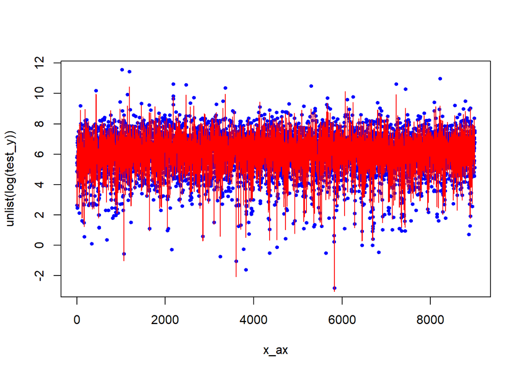

```r
# visualize the model, actual and predicted data
x_ax = 1:length(pred_y)
plot(x_ax, unlist(log(test_y)), col="blue", pch=20, cex=.9)
lines(x_ax, pred_y, col="red", pch=20, cex=.9)
```

- https://www.projectpro.io/recipes/apply-gradient-boosting-r-for-regression

## 解釋

- 最後模型變數重要性排序

在這個資料集，這個模型中我們的目標  
**14.temple_distant temple_distant 1.0315475**  
**(原)15.temple_distant temple_distant 0.95232413**  
排序第 14 名，能造成將近 1% 的影響

Transfer_area_building Transfer_area_building 39.7171740  
Transfer_area_land Transfer_area_land 25.3331823  
Build_YMD Build_YMD 6.2296919  
distance_LRT distance_LRT 3.1934556  
Land_usage_city Land_usage_city 2.8343826  
Li_SSSim Li_SSSim 2.8087025  
distance_train distance_train 2.0378383  
Location_Income Location_Income 1.9146340  
Li_YrSim Li_YrSim 1.8818702  
Town_Season Town_Season 1.6427398

distance_interchange distance_interchange 1.3252772  
X X 1.1628123  
Type_land Type_land 1.1514697  
temple_distant temple_distant 1.0315475  
distance_factory distance_factory 0.8513485  
Land_usage_mt_preservation Land_usage_mt_preservation 0.7521100  
Y Y 0.6307070  
Using_type_L Using_type_L 0.5693446  
distance_airport distance_airport 0.5354369  
Building_age Building_age 0.5005259

TradeYMD TradeYMD 0.4739760  
TtFloor TtFloor 0.4602944  
Build_YM Build_YM 0.4420232  
Using_type_O Using_type_O 0.3851169  
Floor_transfer Floor_transfer 0.3781697  
Using_type_Far Using_type_Far 0.3706803  
Using_type_B Using_type_B 0.3691172  
NoManageOrg NoManageOrg 0.2747802  
Building_Others Building_Others 0.1986361  
Build_Y Build_Y 0.1980771

Building_Apt_general Building_Apt_general 0.12791724  
Floor_complex Floor_complex 0.10165055  
Type_building_with_PS Type_building_with_PS 0.09964161  
Li_Year Li_Year 0.01566876

```r
importance = summary.gbm(model_gbm, plotit=FALSE)
head(importance,34)
```

```
##                                                   var     rel.inf
## Transfer_area_building         Transfer_area_building 39.71717398
## Transfer_area_land                 Transfer_area_land 25.33318231
## Build_YMD                                   Build_YMD  6.22969193
## distance_LRT                             distance_LRT  3.19345561
## Land_usage_city                       Land_usage_city  2.83438256
## Li_SSSim                                     Li_SSSim  2.80870248
## distance_train                         distance_train  2.03783835
## Location_Income                       Location_Income  1.91463404
## Li_YrSim                                     Li_YrSim  1.88187023
## Town_Season                               Town_Season  1.64273982
## distance_interchange             distance_interchange  1.32527718
## X                                                   X  1.16281229
## Type_land                                   Type_land  1.15146968
## temple_distant                         temple_distant  1.03154751
## distance_factory                     distance_factory  0.85134846
## Land_usage_mt_preservation Land_usage_mt_preservation  0.75210998
## Y                                                   Y  0.63070695
## Using_type_L                             Using_type_L  0.56934456
## distance_airport                     distance_airport  0.53543687
## Building_age                             Building_age  0.50052594
## TradeYMD                                     TradeYMD  0.47397602
## TtFloor                                       TtFloor  0.46029444
## Build_YM                                     Build_YM  0.44202317
## Using_type_O                             Using_type_O  0.38511694
## Floor_transfer                         Floor_transfer  0.37816967
## Using_type_Far                         Using_type_Far  0.37068026
## Using_type_B                             Using_type_B  0.36911719
## NoManageOrg                               NoManageOrg  0.27478024
## Building_Others                       Building_Others  0.19863610
## Build_Y                                       Build_Y  0.19807706
## Building_Apt_general             Building_Apt_general  0.12791724
## Floor_complex                           Floor_complex  0.10165055
## Type_building_with_PS           Type_building_with_PS  0.09964161
## Li_Year                                       Li_Year  0.01566876
```

- 畫出前 15 名

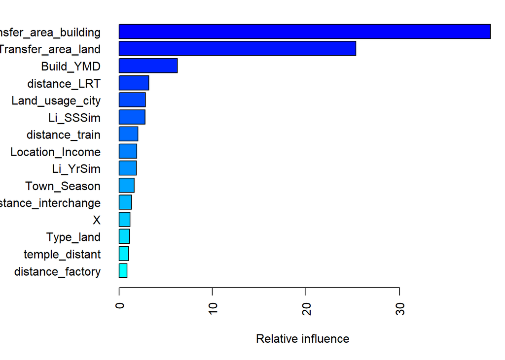

```
##                                                   var     rel.inf
## Transfer_area_building         Transfer_area_building 39.71717398
## Transfer_area_land                 Transfer_area_land 25.33318231
## Build_YMD                                   Build_YMD  6.22969193
## distance_LRT                             distance_LRT  3.19345561
## Land_usage_city                       Land_usage_city  2.83438256
## Li_SSSim                                     Li_SSSim  2.80870248
## distance_train                         distance_train  2.03783835
## Location_Income                       Location_Income  1.91463404
## Li_YrSim                                     Li_YrSim  1.88187023
## Town_Season                               Town_Season  1.64273982
## distance_interchange             distance_interchange  1.32527718
## X                                                   X  1.16281229
## Type_land                                   Type_land  1.15146968
## temple_distant                         temple_distant  1.03154751
## distance_factory                     distance_factory  0.85134846
## Land_usage_mt_preservation Land_usage_mt_preservation  0.75210998
## Y                                                   Y  0.63070695
## Using_type_L                             Using_type_L  0.56934456
## distance_airport                     distance_airport  0.53543687
## Building_age                             Building_age  0.50052594
## TradeYMD                                     TradeYMD  0.47397602
## TtFloor                                       TtFloor  0.46029444
## Build_YM                                     Build_YM  0.44202317
## Using_type_O                             Using_type_O  0.38511694
## Floor_transfer                         Floor_transfer  0.37816967
## Using_type_Far                         Using_type_Far  0.37068026
## Using_type_B                             Using_type_B  0.36911719
## NoManageOrg                               NoManageOrg  0.27478024
## Building_Others                       Building_Others  0.19863610
## Build_Y                                       Build_Y  0.19807706
## Building_Apt_general             Building_Apt_general  0.12791724
## Floor_complex                           Floor_complex  0.10165055
## Type_building_with_PS           Type_building_with_PS  0.09964161
## Li_Year                                       Li_Year  0.01566876
```

```r
par(mar = c(5, 8, 1, 1))
# S3 method for class 'gbm'
summary(
    model_gbm, # gbm object
    cBars = 15, # the number of bars to draw. length(object$var.names)
    plotit = TRUE, # an indicator as to whether the plot is generated.defult TRUE.
    method = relative.influence, # The function used to compute the relative influence. 亦可使用permutation.test.gbm
    las = 2
)
```

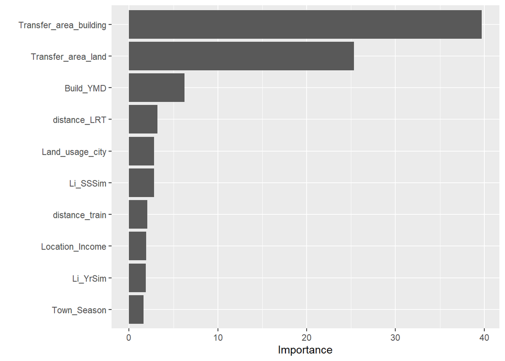

```r
# install.packages('vip')
vip::vip(model_gbm)
```

- https://cloud.tencent.com/developer/article/1058853
- 看前 10 名重要變數 + temple_distant 變動的邊際影響(X軸皆為標準化後尺度)

Transfer_area_building 39.7171740  
Transfer_area_land 25.3331823  
Build_YMD 6.2296919  
distance_LRT 3.1934556  
Land_usage_city 2.8343826  
Li_SSSim 2.8087025  
distance_train 2.0378383  
Location_Income 1.9146340  
Li_YrSim 1.8818702  
Town_Season 1.6427398

temple_distant 1.0315475

**可以看到在0以下確實有著越近寺廟房價越低(exp(6.05) = 424.113萬)，** **越遠離(平均處)房價能上升(exp(6.17) = 478.1861萬)近50萬** **距離寺廟3倍標準差處，其實已經算離群值了，為少數，** **推測過於遠離寺廟處，人煙稀少房價自然也不高/工業區/高級住宅區等等界有可能**

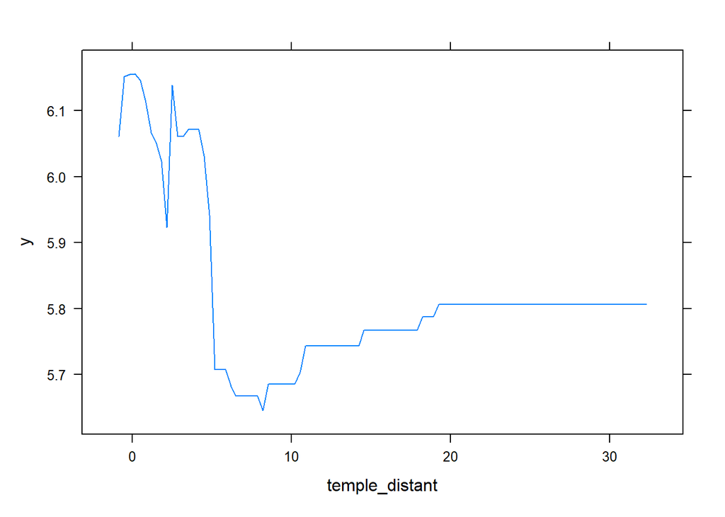

```r
plot.gbm(model_gbm,"temple_distant",besttree)
```

```r
# 可以看到在0以下確實有著越近寺廟房價越低(exp(6.05) = 424.113萬)，
# 越遠離(平均處)房價能上升(exp(6.17) = 478.1861萬)近50萬

# 距離寺廟3倍標準差處，其實已經算離群值了，為少數，
# 推測過於遠離寺廟處，人煙稀少房價自然也不高/工業區/高級住宅區等等界有可能
```

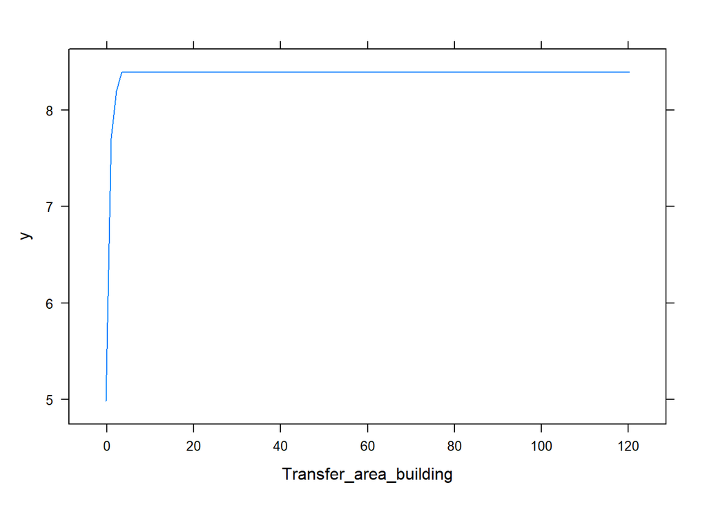

```r
plot.gbm(model_gbm,"Transfer_area_building",besttree)
```

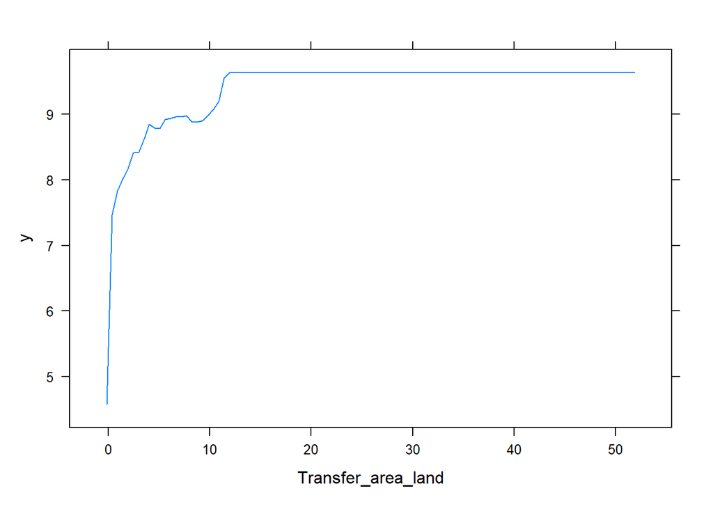

```r
plot.gbm(model_gbm,"Transfer_area_land",besttree)
```

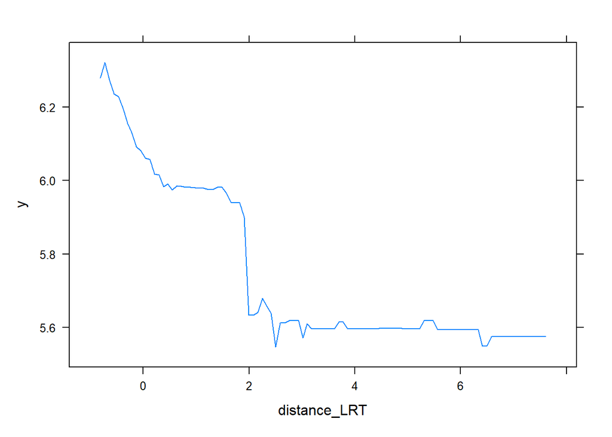

```r
plot.gbm(model_gbm,"distance_LRT",besttree)
```

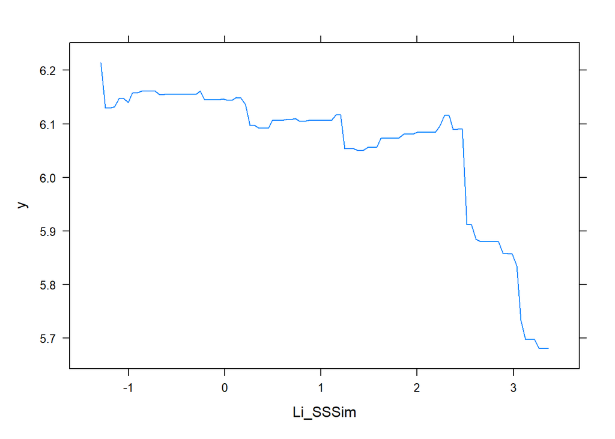

```r
plot.gbm(model_gbm,"Li_SSSim",besttree)
```

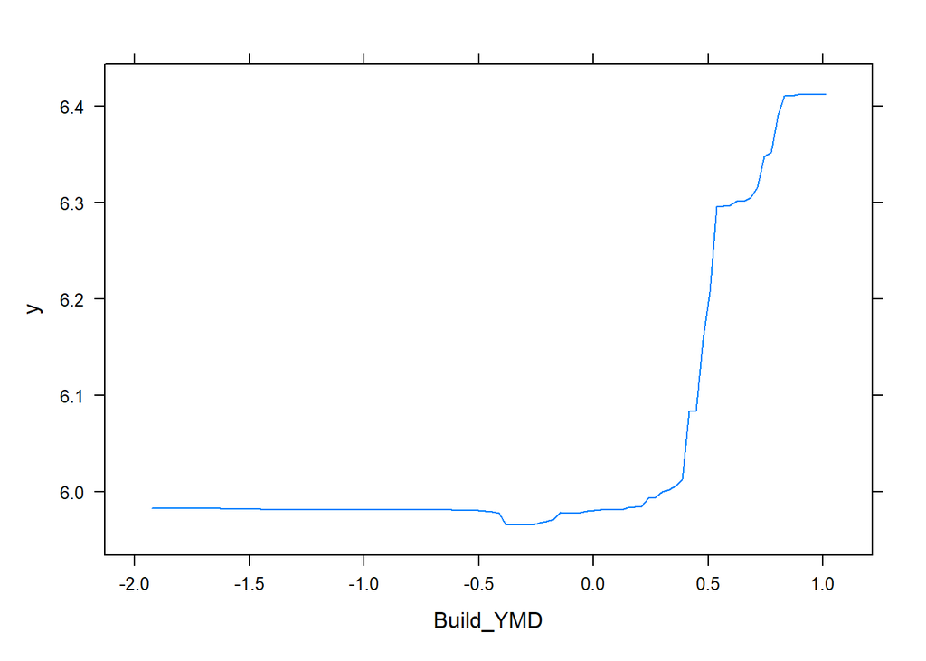

```r
plot.gbm(model_gbm,"Build_YMD",besttree)
```

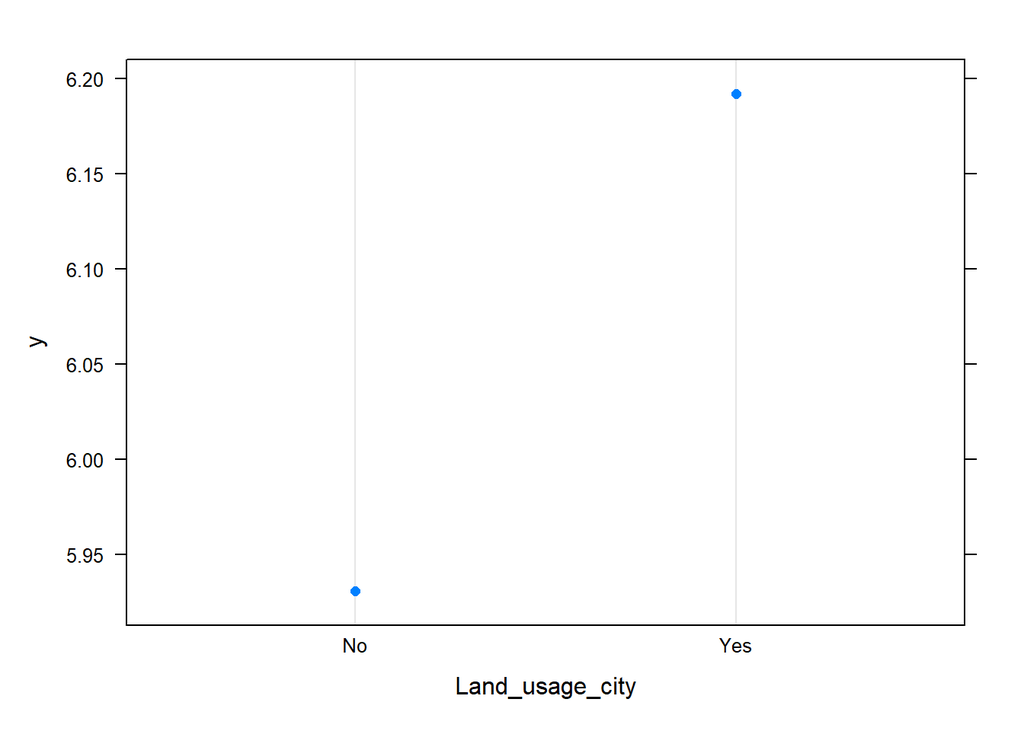

```r
plot.gbm(model_gbm,"Land_usage_city",besttree)
```

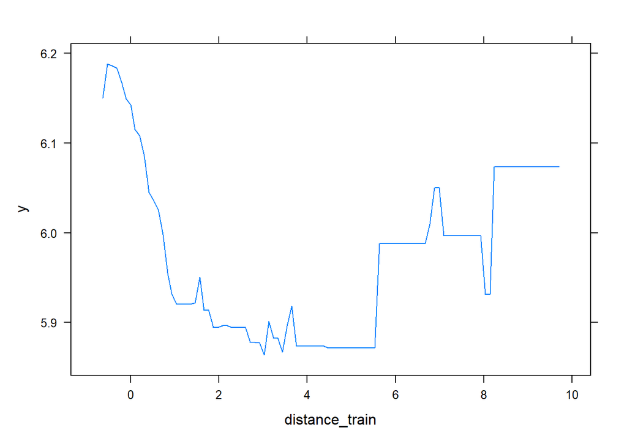

```r
plot.gbm(model_gbm,"distance_train",besttree)
```

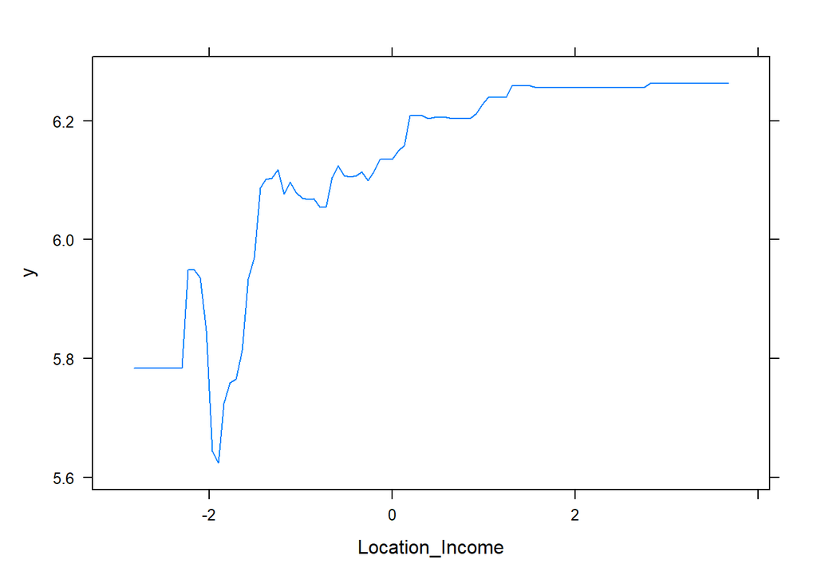

```r
plot.gbm(model_gbm,"Location_Income",besttree)
```

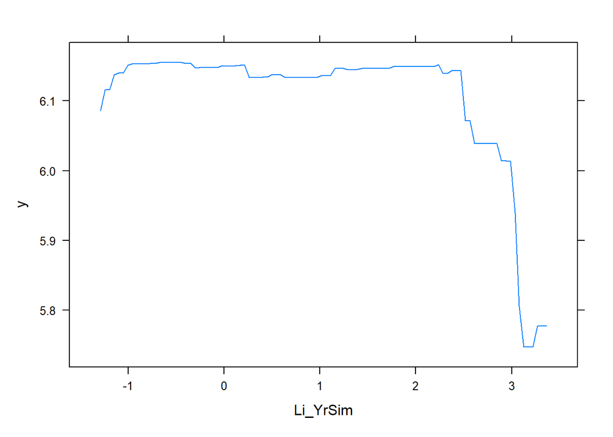

```r
plot.gbm(model_gbm,"Li_YrSim",besttree)
```

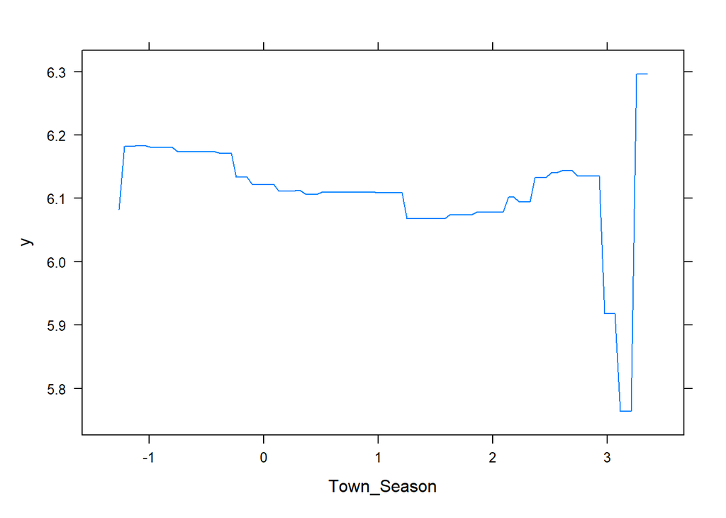

```r
plot.gbm(model_gbm,"Town_Season",besttree)
```